# Initial LS Regression and Cluster Analysis

Kimberley Mitchell

July 17, 2016

Below we perform an initial simple linear regression to take a look at the significance of our independent variables (log of population and total results and city) on the number of days listed.

```r
library(broom)
locs <- read.csv("locs.csv",stringsAsFactors = FALSE)

m3 <- lm(as.numeric(daysListed)~lnPopulation+lnTotalResults+Cityname, data=locs)
    glance(m3)
```

```
##   r.squared adj.r.squared   sigma statistic      p.value  df    logLik
## 1 0.1991821    0.08737692 29.8681   1.78151 8.694885e-22 536 -20749.18
##        AIC      BIC deviance df.residual
## 1 42572.36 45999.53  3418541        3832
```

```r
tm3 <-    tidy(m3)

num_sig <- length(tm3$p.value[tm3$p.value<0.05])
num_sig
```

```
## [1] 42
```

Observation: We see that the overall model is significant, but only 42 values of p significant at the alpha=0.05 level. This does not look like a productive direction to go in model building. Next we will try clustering the cities to find groups of cities in which it will be easier to hire data scientists.

## KMeans clustering to group the cities into clusters

We try several values of k in order to identify a useful numbers of clusters.

```r
locs_nums <- data.frame(cbind(locs$TotalResults,locs$Population,
                              locs$daysListed,locs$lnTotalResults,
                              locs$lnPopulation, locs$lndaysListed))
names(locs_nums) <- c("TotalResults","Population","daysListed",
                      "lnTotalResults","lnPopulation","lndaysListed")


##kmeans clustering
set.seed(321)

k3 <- kmeans(as.matrix(na.omit(locs_nums)),3)
k4 <- kmeans(as.matrix(na.omit(locs_nums)),4)
k5 <- kmeans(as.matrix(na.omit(locs_nums)),5)
k6 <- kmeans(as.matrix(na.omit(locs_nums)),6)
k7 <- kmeans(as.matrix(na.omit(locs_nums)),7)
k8 <- kmeans(as.matrix(na.omit(locs_nums)),8)
k9 <- kmeans(as.matrix(na.omit(locs_nums)),9)
```

The data frame below summarizes the between and within sum of squares errors for the tested number of clusters.

```r
kg <- data.frame(rbind(glance(k3),glance(k4),glance(k5),
                       glance(k6),glance(k7),glance(k8),glance(k9)))
kg <- data.frame(cbind(c(3,4,5,6,7,8,9),kg))
names(kg)[1] <- "num.clusters"
kg
```

```
##   num.clusters       totss tot.withinss    betweenss iter
## 1            3 2.34606e+15 4.123851e+14 1.933675e+15    3
## 2            4 2.34606e+15 2.985750e+14 2.047485e+15    3
## 3            5 2.34606e+15 2.817986e+14 2.064262e+15    3
## 4            6 2.34606e+15 2.755531e+14 2.070507e+15    4
## 5            7 2.34606e+15 2.740952e+14 2.071965e+15    4
## 6            8 2.34606e+15 3.488470e+13 2.311175e+15    5
## 7            9 2.34606e+15 2.989660e+13 2.316163e+15    7
```

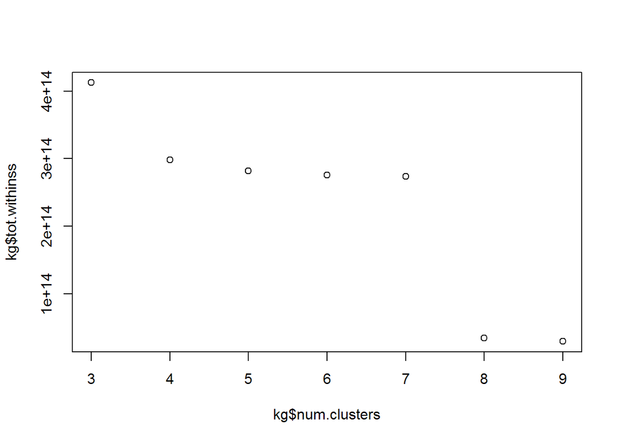

```r
plot(kg$num.clusters,kg$tot.withinss)
```

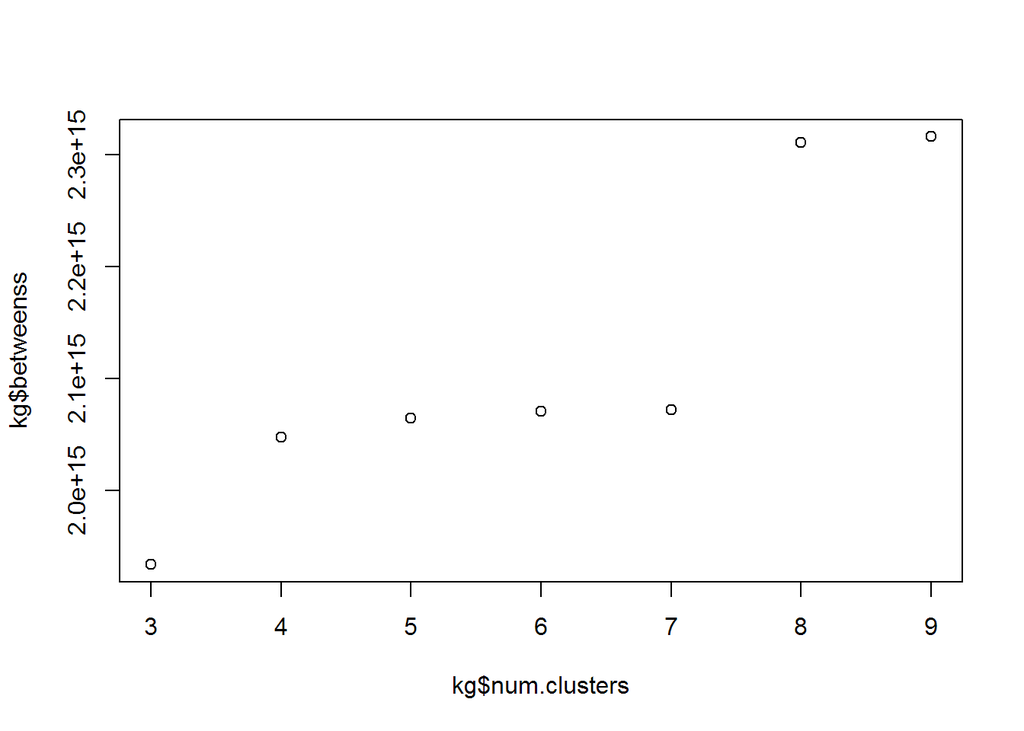

```r
plot(kg$num.clusters,kg$betweenss)
```

## Scatterplot interpretation

Below. we look at a boxplot of the 8 clusters

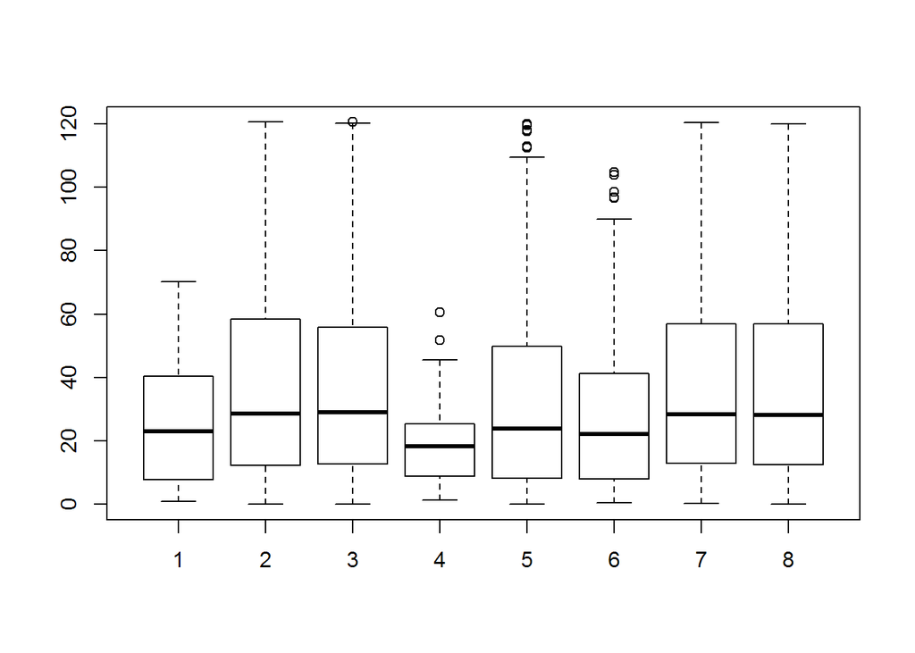

```r
k8aug <- augment(k8,data=na.omit(locs))
boxplot(as.numeric(daysListed)~.cluster, data=k8aug)
```

```r
aggregate(k8aug$daysListed,by=list(k8aug$.cluster),FUN=median)
```

```
##   Group.1        x
## 1       1 22.97052
## 2       2 28.48331
## 3       3 28.97992
## 4       4 18.26274
## 5       5 23.95329
## 6       6 22.13270
## 7       7 28.32263
## 8       8 28.07727
```

```r
aggregate(k8aug$daysListed,by=list(k8aug$.cluster),FUN=mean)
```

```
##   Group.1        x
## 1       1 26.12224
## 2       2 38.16711
## 3       3 36.61711
## 4       4 20.61734
## 5       5 32.61538
## 6       6 29.71443
## 7       7 37.01845
## 8       8 37.08893
```

## Boxplot interpretation

The most obvious difference shown in the boxplot, is cluster 4, which seems to have a shorter list time of the jobs in the cluster.

A list of the median listed days by cluster shows the difference.

```r
m7 <- lm(as.numeric(daysListed)~.cluster, data=k8aug)
glance(m7)
```

```
##     r.squared adj.r.squared    sigma statistic     p.value df    logLik
## 1 0.007107191   0.005500568 31.13548  4.423684 6.56095e-05  8 -21047.48
##        AIC      BIC deviance df.residual
## 1 42112.95 42170.32  4193704        4326
```

```r
tidy(m7)
```

```
##          term  estimate std.error  statistic      p.value
## 1 (Intercept) 26.122241  4.447926  5.8729032 4.603405e-09
## 2   .cluster2 12.044866  4.515188  2.6676334 7.667224e-03
## 3   .cluster3 10.494870  4.605623  2.2787080 2.273295e-02
## 4   .cluster4 -5.504897  7.757350 -0.7096363 4.779680e-01
## 5   .cluster5  6.493140  4.681307  1.3870355 1.655024e-01
## 6   .cluster6  3.592190  5.123167  0.7011659 4.832372e-01
## 7   .cluster7 10.896208  4.691758  2.3224145 2.025681e-02
## 8   .cluster8 10.966687  4.563110  2.4033363 1.628807e-02
```

## Linear Model Test

So which cities are in this cluster??? This shall be revealed, below!

```r
k8aug$Cityname[k8aug$.cluster==4]
```

```
##  [1] "New York NY" "New York NY" "New York NY" "New York NY" "New York NY"
##  [6] "New York NY" "New York NY" "New York NY" "New York NY" "New York NY"
## [11] "New York NY" "New York NY" "New York NY" "New York NY" "New York NY"
## [16] "New York NY" "New York NY" "New York NY" "New York NY" "New York NY"
## [21] "New York NY" "New York NY" "New York NY" "New York NY"
```

This is being proposed as an initial exploratory effort. Work on this effort has highlighted some significant issues with the data which need to be resolved prior to any final conclusions.

– K.Mitchell